# Predicting MNIST Handwritten Digits With Convolutional Neural Network

When creating a convolutional neural network (CNN), it can be difficult to decide what kind of architecture to use. The typical approach is to begin with an architecture that has worked well for a similar problem and adjust it to work on yours. This technique is called transfer learning. However, fine-tuning a network's architecture can still be daunting because of the vast number of adjustments that could be made. In this notebook, we will explore one approach to tuning convolutional neural network architectures by developing successive autoencoders that attempt to maximize the amount of information retained upon each subsampling step. We will be working with the popular MNIST handwritten digits dataset, and our goal will be to discover the simplest CNN architecture that still produces excellent results. In the end, we will produce a model that is 99.4% accurate when evaluated on the hidden Kaggle dataset.

We will begin by importing modules from the libraries we are going to use and by loading the csv files into pandas DataFrames.

```python
# standard imports
from copy import deepcopy
import os
import sys
import traceback
import math
import pickle
import random

# third party imports
import torch as t
import numpy as np
import pandas as pd
import matplotlib.pyplot as plt
from sklearn.model_selection import train_test_split

if t.cuda.is_available(): device = "cuda" # using gpu
else: device = "cpu"
```

```python
# load the training data which contains labels in column 0
train_df = pd.read_csv(os.path.join(os.path.dirname(sys.path[0]), "MNIST_CNN_notebook/train.csv"), header=0, index_col=False)
labels_df = train_df["label"]
train_df.drop(columns = ["label"], inplace=True)

# load the testing data which does not contain any labels
test_df = pd.read_csv(os.path.join(os.path.dirname(sys.path[0]), "MNIST_CNN_notebook/test.csv"), header=0, index_col=False)
```

Let's look at the shape of these DataFrames and make sure that they are not missing any values:

```python
print(f"Training input dataset has shape {train_df.shape}.")
print(f"Training labels dataset has shape {labels_df.shape}.")
print(f"Testing input dataset has shape {test_df.shape}.")
print(f"Training input dataset is missing {sum(pd.isna(train_df).any())} entries.")
print(f"Training labels dataset is missing {sum(pd.isna(labels_df))} entries.")
print(f"Testing input dataset is missing {sum(pd.isna(test_df).any())} entries.")
```

```
Training input dataset has shape (42000, 784).
Training labels dataset has shape (42000,).
Testing input dataset has shape (28000, 784).
Training input dataset is missing 0 entries.
Training labels dataset is missing 0 entries.
Testing input dataset is missing 0 entries.
```

Now Let's convert the datasets to numpy.ndarrays and reformat each sample to have shape 28 x 28 instead of 1 x 784. We will also plot some random samples to make sure that they look properly formatted.

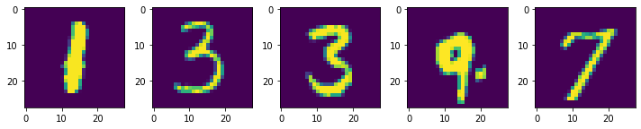

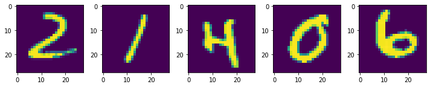

```python
# convert to numpy.ndarrays and reshape
train_images = train_df.to_numpy().astype(np.float32).reshape(len(train_df), 28, 28)
test_images = test_df.to_numpy().astype(np.float32).reshape(len(test_df), 28, 28)

# get the indices of some random samples from train and test datasets
random_train_indices = random.sample(range(0, len(train_images)), 5)
random_test_indices = random.sample(range(0, len(test_images)), 5)

# plot train samples
fig1=plt.figure(figsize=(10,5))
for i, index in enumerate(random_train_indices):
    ax=fig1.add_subplot(1,5,i+1)
    ax.imshow(train_images[index])

# plot test samples
fig2=plt.figure(figsize=(10,5))
for i, index in enumerate(random_test_indices):
    ax=fig2.add_subplot(1,5,i+1)
    ax.imshow(test_images[index])

# show plots (test appears below train)
fig1.tight_layout()
fig2.tight_layout()
plt.show()
```

The samples look properly oriented, which is great! Before we proceed to developing our model. Let's save these numpy.ndarrays as .npy files so that they can be loaded from storage more quickly each time the program is run.

```python
# save reshaped images as .npy files for faster loading
np.save("C:/Users/Tobias/OneDrive/Desktop/DataProjects/MNIST/Datasets/train_images.npy", train_images)
np.save("C:/Users/Tobias/OneDrive/Desktop/DataProjects/MNIST/Datasets/test_images.npy", test_images)
np.save("C:/Users/Tobias/OneDrive/Desktop/DataProjects/MNIST/Datasets/train_labels.npy", train_labels)
```

Now let's construct the first of our autoencoding convolutional neural network architectures. The encoder section will consists of two 3x3 convolutional layers and exactly one 5x5 downsampling convolutional layer. The 3x3 layers will be defined such that they do not reduce the dimensionality of the input (stride=1, padding=1), while the 5x5 layer will be defined such that it reduces the dimensionality of the input by a factor of 2 (stride=2, padding=2). Having two of the 3x3 Convolutional layers should allow the model to capture any nonlinear structural relationships in the input. Our job will be to determine the minimum number of filters/kernels required by each of these convolutions to maximize the autoencoder's ability to reproduce the input. The decoder portion of the autoencoder will have a symmetrical structure to the encoder's so that its output matches the original input. We define the autoencoder architecture below.

```python
class AutoEncoder(t.nn.Module):
    def __init__(self, num_filters, input_filters, dropout):
        # num_filters (int): indicates the number of filters/kernel functions used during each convolution
        # input_filters (int): indicates the number of filters/kernel functions possessed by the input
        # dropout (float): represents the proportion of neurons randomly ignored at each convolutional
        #                  layer of the network. This can help regularize/generalize the model

        super().__init__()

        # encoder
        self.encoder = t.nn.Sequential(
            t.nn.Conv2d(1, num_filters, 3, stride=1, padding=1),
            t.nn.BatchNorm2d(num_filters), # we apply batch normalization after each convolution
            t.nn.ReLU(inplace=True), # we use ReLU as our activation function
            t.nn.Dropout(dropout),
            t.nn.Conv2d(num_filters, num_filters, 3, padding=1),
            t.nn.BatchNorm2d(num_filters),
            t.nn.ReLU(inplace=True),
            t.nn.Dropout(dropout),
            t.nn.Conv2d(num_filters, num_filters, kernel_size=5, stride=2, padding=2),
        )

        # decoder
        self.decoder = t.nn.Sequential(
            t.nn.ConvTranspose2d(num_filters, num_filters, kernel_size=5, stride=2, padding=2, output_padding=(1 if (input_filters%2)==0 else 0),
            t.nn.BatchNorm2d(num_filters),
            t.nn.ReLU(inplace=True),
            t.nn.Dropout(dropout),
            t.nn.ConvTranspose2d(num_filters, num_filters, kernel_size=3, stride=1, padding=1),
            t.nn.BatchNorm2d(num_filters),
            t.nn.ReLU(inplace=True),
            t.nn.Dropout(dropout),
            t.nn.ConvTranspose2d(num_filters, 1, kernel_size=3, stride=1, padding=1),
        )

    def forward(self, x):
        return self.decoder(self.encoder(x))
```

We will compare the ability of this architecture to summarize and reproduce the original input using different numbers of filters/kernel functions at each convolutional layer. We will first evaluate the architecture with 8 filters at each layer and increase the number of filters used by a factor of two until the model's performance no longer increases. For the sake of computational complexity, we will not test an architecture using more than 128 filters at any convolutional layer. We will also tune the model's learning rate, weight decay and dropout proportion for each architecture as the effect of these hyperparameters will change as the number of parameters contained within the model changes.

Another hyperparameter that is going to have different effects depending on the number of filters used is how long the model is trained for. In order to maintain consistency accross the different architectures, we will look at how long it takes to train the most complex of the potential architectures. The following method trains an architecture with 128 filters in each convolutional layer and records the training and test validation scores at each epoch.

```python
train_images = t.tensor(np.load("C:/Users/Tobias/OneDrive/Desktop/DataProjects/MNIST/Datasets/train_images.npy")).unsqueeze(1)
#train_images = t.tensor(np.load("C:/Users/Tobias/OneDrive/Desktop/DataProjects/MNIST/Datasets/encoded_train_images.npy"))
#train_images = t.tensor(np.load("C:/Users/Tobias/OneDrive/Desktop/DataProjects/MNIST/Datasets/second_encoded_train_images.npy"))

# shuffle dataset
permutation = np.random.permutation(len(train_images))
train_images = train_images[permutation]

# define the loss to be mean squared error
criterion = t.nn.MSELoss()

# will use 10% of training data for cross validation
cv_size = int(train_images.shape[0]*0.1)
batch_size = 2**9 # largest batch_size that my gpu can hold without running out of memory

# keep track of training and validation loss at each epoch
train_loss_recordings = pd.DataFrame(columns=["0.03", "0.003", "0.0003"])
validation_loss_recordings = pd.DataFrame(columns=["0.03", "0.003", "0.0003"])
for lr in [0.03,0.003,0.0003]:
    train_X, test_X = train_images[:-cv_size], train_images[-cv_size:]

    # put input into (0,1) range
    normalizing_constant = t.max(train_X).item()
    train_X = train_X/normalizing_constant
    test_X = test_X/normalizing_constant

    # define the model
    model = AutoEncoder(num_filters=128, dropout=0, input_layers=train_images.shape[1]).to(device=device)
    optimizer = t.optim.Adam(params=model.parameters(), lr=lr)

    # train model
    testloader = t.utils.data.DataLoader(test_X, batch_size=2**9, shuffle=False, num_workers=0)
    train_losses = []
    validation_losses = []
    for m in range(100):
        running_loss = 0
        trainloader = t.utils.data.DataLoader(train_X, batch_size=2**9, shuffle=True, num_workers=0)
        model.train()
        for i, input in enumerate(trainloader):
            optimizer.zero_grad()
            input = input.to(device=device)
            predictions = model(input)
            loss = criterion(predictions, input)
            loss.backward()
            optimizer.step()
            running_loss += loss.item()
        print(f"lr {lr}, Epoch {m} training loss: {running_loss/(math.ceil(len(train_X)/(2**9)))}.")
        train_losses.append(running_loss/(math.ceil(len(train_X)/(2**9))))

        running_loss = 0
        model.eval()
        with t.no_grad():
            for i, input in enumerate(testloader):
                input = input.to(device=device)
                validation_predictions = model(input)
                loss = criterion(validation_predictions, input)
                running_loss += loss.item()
        validation_losses.append(running_loss/(math.ceil(len(test_X)/(2**9))))

        print(f"lr {lr}, Epoch {m} validation loss: {running_loss/(math.ceil(len(test_X)/(2**9)))}")

    train_loss_recordings[str(lr)] = train_losses
    validation_loss_recordings[str(lr)] = validation_losses
train_loss_recordings.to_csv(os.path.join(os.path.dirname(sys.path[0]), "MNIST_CNN_notebook/initial_model_measurements/training_measurements1.csv"))
validation_loss_recordings.to_csv(os.path.join(os.path.dirname(sys.path[0]), "MNIST_CNN_notebook/initial_model_measurements/validation_measurements1.csv"))
```

Let's visualize how the training and validation losses change as a function of the number of epochs for which the network was trained.

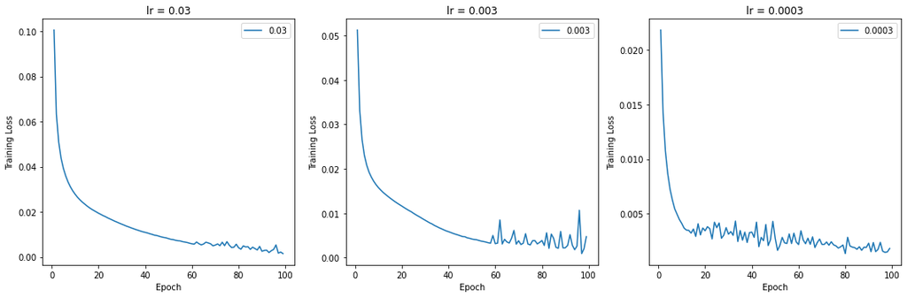

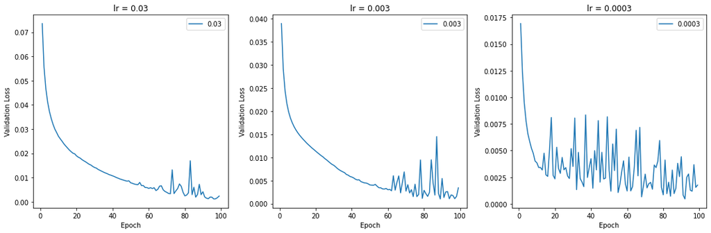

```python
training_losses = pd.read_csv(os.path.join(os.path.dirname(sys.path[0]), "MNIST_CNN_notebook/initial_model_measurements/training_measurements1.csv"), header=0, index_col=0)
validation_losses = pd.read_csv(os.path.join(os.path.dirname(sys.path[0]), "MNIST_CNN_notebook/initial_model_measurements/validation_measurements1.csv"), header=0, index_col=0)

fig1 = plt.figure(figsize=(15,5))
for n, column in enumerate(training_losses.columns):
    ax = fig1.add_subplot(1,3,n+1)
    training_losses.iloc[1:].plot(y=column, use_index=True, ax=ax)
    ax.set_title("lr = " + str(column))
    ax.set_xlabel("Epoch")
    ax.set_ylabel("Training Loss")
fig1.tight_layout()

fig2 = plt.figure(figsize=(15,5))
for n, column in enumerate(validation_losses.columns):
    ax = fig2.add_subplot(1,3,n+1)
    validation_losses.iloc[1:].plot(y=column, use_index=True, ax=ax)
    ax.set_title("lr = " + str(column))
    ax.set_xlabel("Epoch")
    ax.set_ylabel("Validation Loss")
fig2.tight_layout()
plt.show()
```

As we can see from the graphs above, when using the best learning rate (0.0003 for 128 filters), an architecture using 128 filters will have converged after about 25 epochs. To be safe, we will train each architecture for a maximum of 40 epochs, but will introduce a tolerance of 5 epochs (training will converge after 5 epochs with no improvement in validation score).

Below we define the cross validation function we are going to use as well as a helper function for tuning hyperparameters.

```python
# a method to train and evaluate a model
def cross_validate_autoencoder(X, num_cvs, optimizer_params, network_params, training_params, print_loss:bool = False):
    # shuffle dataset
    permutation = np.random.permutation(len(X))
    X = X[permutation]

    # perform a fold of cross validation
    criterion = t.nn.MSELoss()
    batch_size = 2**training_params["batch_size_exponent"]
    cv_size = int(X.shape[0]/num_cvs)
    avg_loss = 0
    for n in range(num_cvs):
        # split the dataset into training and cross validation sets:
        if n == num_cvs-1:
            train_X, test_X = X[:-cv_size], X[-cv_size:]
        else:
            train_X, test_X = t.cat([X[:cv_size*n], X[cv_size*(n+1):]], dim=0), X[cv_size*n:cv_size*(n+1)]

        # put input into (0,1) range
        normalizing_factor = t.max(train_X).item()
        train_X = train_X/normalizing_factor
        test_X = test_X/normalizing_factor

        # define the model
        model = AutoEncoder(**network_params).to(device=device)
        optimizer = t.optim.Adam(params=model.parameters(), **optimizer_params)

        # train model
        smallest_validation = np.inf
        tolerance_counter = 0
        #callback_model = None # would use this to hold the best model if we were keeping track
        testloader = t.utils.data.DataLoader(test_X, batch_size=batch_size, shuffle=False, num_workers=0)
        scheduler = t.optim.lr_scheduler.LambdaLR(optimizer, lambda x: 0.95**x)
        for m in range(training_params["max_epochs"]):
            running_loss = 0
            trainloader = t.utils.data.DataLoader(train_X, batch_size=batch_size, shuffle=True, num_workers=0)
            model.train()
            for i, input in enumerate(trainloader):
                optimizer.zero_grad()
                input = input.to(device=device)
                predictions = model(input)
                loss = criterion(predictions, input)
                loss.backward()
                optimizer.step()
                running_loss += loss.item()
            scheduler.step()
                #if print_loss: print(f"Epoch {m}, iteration {i}, running loss: {running_loss}.")
            if print_loss: print(f"Epoch {m} training loss: {running_loss/(math.ceil(len(train_X)/batch_size))}.")

            running_loss = 0
            with t.no_grad():
                model.eval()
                for i, input in enumerate(testloader):
                    input = input.to(device=device)
                    validation_predictions = model(input)
                    loss = criterion(validation_predictions, input)
                    running_loss += loss.item()

            if running_loss >= smallest_validation: tolerance_counter+=1
            else:
                #callback_model = deepcopy(model).cpu() # would use this to retrieve the model after training if we wanted
                smallest_validation = running_loss
                tolerance_counter = 0
            if print_loss: print(f"Epoch {m} validation loss: {running_loss/(math.ceil(len(test_X)/batch_size))}")
            if tolerance_counter > training_params["tolerance"]: break
        # using best validation
        avg_loss += smallest_validation/(math.ceil(len(test_X)/batch_size))
    return avg_loss/num_cvs


# a method to be called for each of the architectures to perform hyperparameter tuning
def fit_autoencoder_hyperparameters(num_filters, search_distance, csv_file):
    # define cv_function that takes only hyperparameters:
    def cv_function(tracked_hyperparameters:dict):
        # make sure that hyperparameters are valid
        if tracked_hyperparameters["batch_size_exponent"] > 11: return -np.inf # exceeds memory limit
        if tracked_hyperparameters["dropout"] < 0 or tracked_hyperparameters["dropout"] > 1: return -np.inf # dropout must be in [0,1]
        if tracked_hyperparameters["weight_decay"] < 0: return -np.inf # weight decay must be non-negative
        if tracked_hyperparameters["lr"] <=0: return -np.inf # lr must be positive

        # define network hyperparameters:
        optimizer_params = {}
        optimizer_params["lr"] = tracked_hyperparameters["lr"]
        optimizer_params["weight_decay"] = tracked_hyperparameters["weight_decay"]
        network_params = {}
        network_params["dropout"] = tracked_hyperparameters["dropout"]

        # define constant hyperparameters
        network_params["num_filters"] = num_filters

        # cross validate the model
        return -cross_validate_autoencoder(optimizer_params, network_params, train_images, num_cvs, num_epochs, 2**tracked_hyperparameters["batch_size_exponent"],
                                              print_loss=False, print_gradients=False)

    # define hyperparameter information that the search depends on
    tracked_hyperparameter_names = {"lr", "weight_decay", "dropout", "batch_size_exponent"}
    constant_hyperparameters = {}
    integer_hyperparameters = {"batch_size_exponent"}
    list_hyperparameters = {}

    # perform search using cv_function and hyperparameters defined above
    hyperparameter_search.initial_search(csv_file, cv_function, tracked_hyperparameter_names, constant_hyperparameters,
        integer_hyperparameters, list_hyperparameters, num_rounds = 1, search_distance=search_distance, print_status = True,
        dtype=np.float64)
```

We will use 5-fold cross validations to evaluate each model.

```python
train_images = t.tensor(np.load(os.path.join(os.path.dirname(sys.path[0]), "MNIST_CNN_notebook/Datasets/train_images.npy"))).unsqueeze(1)

# define network hyperparameters:
optimizer_params = {
    "lr": 0.003,
    "weight_decay": 0.001,
}
network_params = {
    "num_filters":8, # this chooses which architecture is being used
    "dropout": 0.01,
}
batch_size_exponent = 9 # the batch size will be 2 to the power of this argument (2**batch_size_exponent)

# cross validate the model
avg_loss = cross_validate_autoencoder(optimizer_params, network_params, train_images, num_cvs, num_epochs, 2**batch_size_exponent, print_loss=True, print_gradients=False)
print(f"Average cross validation loss: {avg_loss}")

# save hyperparameters in csv
csv_folder = os.path.join(os.path.dirname(sys.path[0]), "MNIST_CNN_notebook/hyperparameter_files")
csv_filename = csv_folder + "/" + str(network_params["num_filters"]) + "num_filters1.csv"
try:
    hyperparameter_table = pd.read_csv(csv_filename, header=0, index_col=0)
except FileNotFoundError:
    hyperparameter_table = pd.DataFrame(columns=["lr", "weight_decay", "dropout", "batch_size_exponent", "log_likelihood"])
tracked_hyperparameters = deepcopy(optimizer_params)
tracked_hyperparameters["dropout"] = network_params["dropout"]
tracked_hyperparameters["batch_size_exponent"] = batch_size_exponent
tracked_hyperparameters["log_likelihood"] = -avg_loss
hyperparameter_table.loc[len(hyperparameter_table.index)] = tracked_hyperparameters
hyperparameter_table.to_csv(csv_filename)
```

Now we can run a simple tuning function to improve these hyperparameters. The tuning function will perform a binary search along each of the given hyperparameters with the magnitudes defined below.

```python
search_distances = {
    "lr": 1,
    "weight_decay": 1,
    "dropout": 1,
    "batch_size_exponent": 0.2
}

# perform search
num_filters = 8
csv_folder = os.path.join(os.path.dirname(sys.path[0]), "MNIST_CNN_notebook/hyperparameter_files")
csv_file = csv_folder + "/" + str(num_filters) + "num_filters1.csv"
train_images = t.tensor(np.load(os.path.join(os.path.dirname(sys.path[0]), "MNIST_CNN_notebook/Datasets/train_images.npy"))).unsqueeze(1)
fit_autoencoder_hyperparameters(num_filters, search_distances, csv_file)
```

Let's print the results for the first three model architectures (8, 16, and 32 filters per convolutional layer).

```python
# credit for this method goes to user ntg on stackoverflow (https://stackoverflow.com/questions/38783027/jupyter-notebook-display-two-pandas-tables-side-by-side)
from IPython.display import display_html
from itertools import chain,cycle
def display_side_by_side(*args,titles=cycle([''])):
    html_str=''
    for df,title in zip(args, chain(titles,cycle(['</br>'])) ):
        html_str+='<th style="text-align:center"><td style="vertical-align:top">'
        html_str+=f'<h2 style="text-align: center;">{title}</h2>'
        html_str+=df.to_html().replace('table','table style="display:inline"')
        html_str+='</td></th>'
    display_html(html_str,raw=True)

df1 = pd.read_csv(os.path.join(os.path.dirname(sys.path[0]), "MNIST_CNN_notebook/hyperparameter_files/8num_filters1.csv"),
    header=0, index_col=0).reset_index().drop(columns=["index"]).reset_index().drop(columns=["index"]).sort_values("log_likelihood")
df2 = pd.read_csv(os.path.join(os.path.dirname(sys.path[0]), "MNIST_CNN_notebook/hyperparameter_files/16num_filters1.csv"),
    header=0, index_col=0).reset_index().drop(columns=["index"]).reset_index().drop(columns=["index"]).sort_values("log_likelihood")
df3 = pd.read_csv(os.path.join(os.path.dirname(sys.path[0]), "MNIST_CNN_notebook/hyperparameter_files/32num_filters1.csv"),
    header=0, index_col=0).reset_index().drop(columns=["index"]).reset_index().drop(columns=["index"]).sort_values("log_likelihood")
display_side_by_side(df1,df2,df3, titles=["8 filters","16 filters", "32 filters"])
```

8 filters

|  | lr | weight_decay | dropout | batch_size_exponent | log_likelihood |
| --- | --- | --- | --- | --- | --- |
| 16 | 0.0060 | 0.00025 | 0.00250 | 8 | -0.002070 |
| 13 | 0.0060 | 0.00040 | 0.00250 | 8 | -0.000888 |
| 10 | 0.0060 | 0.00010 | 0.00375 | 8 | -0.000876 |
| 2 | 0.0120 | 0.00010 | 0.01000 | 8 | -0.000848 |
| 14 | 0.0060 | 0.00030 | 0.00250 | 8 | -0.000771 |
| 5 | 0.0060 | 0.00010 | 0.02000 | 8 | -0.000761 |
| 4 | 0.0045 | 0.00010 | 0.01000 | 8 | -0.000670 |
| 0 | 0.0030 | 0.00010 | 0.01000 | 8 | -0.000668 |
| 15 | 0.0060 | 0.00015 | 0.00250 | 8 | -0.000470 |
| 3 | 0.0090 | 0.00010 | 0.01000 | 8 | -0.000450 |
| 1 | 0.0060 | 0.00010 | 0.01000 | 8 | -0.000439 |
| 8 | 0.0060 | 0.00010 | 0.00750 | 8 | -0.000435 |
| 12 | 0.0060 | 0.00020 | 0.00250 | 8 | -0.000291 |
| 7 | 0.0060 | 0.00010 | 0.00500 | 8 | -0.000237 |
| 11 | 0.0060 | 0.00010 | 0.00125 | 8 | -0.000232 |
| 6 | 0.0060 | 0.00010 | 0.00000 | 8 | -0.000190 |
| 9 | 0.0060 | 0.00010 | 0.00250 | 8 | -0.000148 |

16 filters

|  | lr | weight_decay | dropout | batch_size_exponent | log_likelihood |
| --- | --- | --- | --- | --- | --- |
| 8 | 0.0120 | 0.00010 | 0.020 | 8 | -0.001763 |
| 9 | 0.0090 | 0.00010 | 0.020 | 8 | -0.001433 |
| 14 | 0.0060 | 0.00015 | 0.020 | 8 | -0.001298 |
| 3 | 0.0030 | 0.00010 | 0.030 | 8 | -0.000879 |
| 5 | 0.0030 | 0.00010 | 0.020 | 8 | -0.000804 |
| 0 | 0.0030 | 0.00010 | 0.010 | 8 | -0.000752 |
| 2 | 0.0030 | 0.00010 | 0.040 | 8 | -0.000740 |
| 12 | 0.0060 | 0.00020 | 0.020 | 8 | -0.000689 |
| 4 | 0.0030 | 0.00010 | 0.015 | 8 | -0.000688 |
| 13 | 0.0060 | 0.00000 | 0.020 | 8 | -0.000668 |
| 10 | 0.0045 | 0.00010 | 0.020 | 8 | -0.000624 |
| 1 | 0.0030 | 0.00010 | 0.020 | 8 | -0.000583 |
| 6 | 0.0030 | 0.00010 | 0.020 | 8 | -0.000532 |
| 16 | 0.0060 | 0.00010 | 0.020 | 8 | -0.000531 |
| 15 | 0.0060 | 0.00005 | 0.020 | 8 | -0.000447 |
| 11 | 0.0075 | 0.00010 | 0.020 | 8 | -0.000433 |
| 7 | 0.0060 | 0.00010 | 0.020 | 8 | -0.000281 |

32 filters

|  | lr | weight_decay | dropout | batch_size_exponent | log_likelihood |
| --- | --- | --- | --- | --- | --- |
| 1 | 0.00060 | 0.00010 | 0.020 | 8 | -0.001603 |
| 10 | 0.00300 | 0.00005 | 0.015 | 8 | -0.001165 |
| 12 | 0.00150 | 0.00010 | 0.015 | 8 | -0.001092 |
| 2 | 0.00300 | 0.00010 | 0.040 | 8 | -0.000908 |
| 13 | 0.00450 | 0.00010 | 0.015 | 8 | -0.000885 |
| 11 | 0.00600 | 0.00010 | 0.015 | 8 | -0.000880 |
| 0 | 0.00300 | 0.00010 | 0.020 | 8 | -0.000830 |
| 7 | 0.00300 | 0.00020 | 0.015 | 8 | -0.000732 |
| 8 | 0.00300 | 0.00000 | 0.015 | 8 | -0.000670 |
| 6 | 0.00300 | 0.00010 | 0.005 | 8 | -0.000592 |
| 3 | 0.00300 | 0.00010 | 0.000 | 8 | -0.000570 |
| 14 | 0.00225 | 0.00010 | 0.015 | 8 | -0.000552 |
| 9 | 0.00300 | 0.00015 | 0.015 | 8 | -0.000502 |
| 4 | 0.00300 | 0.00010 | 0.010 | 8 | -0.000446 |
| 5 | 0.00300 | 0.00010 | 0.015 | 8 | -0.000438 |

We can see from the results above that there is no significant improvement in the autoencoder's ability to reproduce the input upon increasing the number of filters used from 8 to 16 or 32. For context, the log_likelihood scores represent the negative of the average squared difference between input image and output image. The small scores we see mean that the autoencoder is easily able to capture almost all of the information contained within the original 28 x 28 input in a smaller but deeper 8 x 14 x 14 dimensional encoded form. Since there was no improvement shown in the 16 or 32 filter architectures, we will avoid unecessarily testing 64 and 128 filter architectures and use 8 filters for the first portion of our model.

The next step is to repeat this process one subsampling layer deeper, encoding each original 28 x 28 input image as an num_filters x 7 x 7 encoding. In order to reduce the the computational workload of evaluating the next set of autoencoders, instead of training with the original 28 x 28 input and trying to reproduce it, we will train a version of the previous autoencoder and run all of the training images through the encoder portion of the network to produce encoded images of shape 8 x 14 x 14 which we will train the next autoencoder to reproduce. This technique for training autoencoders in sections greatly reduces the amount of computation required to train deep autoencoders and leads to almost no information loss since we have already decided on the architecture for the previous section(s) of the autoencoder.

```python
# load original training images (each 28 x 28)
images = t.tensor(np.load(os.path.join(os.path.dirname(sys.path[0]), "MNIST_CNN_notebook/Datasets/train_images.npy")).unsqueeze(1)

# shuffle dataset
permutation = np.random.permutation(len(images))
images = images[permutation]

# split images into training and validation
cv_size = int(len(images)*0.1) # using ten percent of images for validation
train_images, test_images = images[:-cv_size], images[-cv_size:]

# put input into (0,1) range
normalizing_constant = t.max(train_images).item()
train_images = train_images/normalizing_constant
test_images = test_images/normalizing_constant

# define hyperparameters
num_filters = 8 # best num_filters
dropout = 0.0 # best dropout
lr = 0.006 #  best lr
weight_decay = 1e-4 # best weight_decay
batch_size_exponent = 8

# define the model
model = AutoEncoder(num_filters, 1 dropout).to(device=device)
optimizer = t.optim.Adam(params=model.parameters(), lr=lr, weight_decay=weight_decay)
criterion = t.nn.MSELoss()
callback_model = None # holds the best validation model during training

# define DataLoaders for training and validating in batches
trainloader = t.utils.data.DataLoader(train_images, batch_size=2**batch_size_exponent, shuffle=True, num_workers=0)
testloader = t.utils.data.DataLoader(test_images, batch_size=2**batch_size_exponent, shuffle=False, num_workers=0)

# train the model
scheduler = t.optim.lr_scheduler.LambdaLR(optimizer, lambda x: 0.95**x)
smallest_validation = np.inf
tolerance_counter = 0
for m in range(40):
    running_loss = 0
    for i, input in enumerate(trainloader):
        optimizer.zero_grad()
        input = input.to(device=device)
        predictions = model(input)
        loss = criterion(predictions, input)
        loss.backward()
        optimizer.step()
        running_loss += loss.item()

    print(f"Epoch {m} loss: {running_loss/math.ceil(len(train_images)/(2**batch_size_exponent))}.")

    running_loss = 0
    with t.no_grad():
        model.eval()
        for i, input in enumerate(testloader):
            input = input.to(device=device)
            validation_predictions = model(input)
            loss = criterion(validation_predictions, input)
            running_loss += loss.item()

    if running_loss >= smallest_validation: tolerance_counter+=1
    else:
        callback_model = deepcopy(model).cpu()
        smallest_validation = running_loss
        tolerance_counter = 0
    if tolerance_counter > 5: break

# save recreated and encoded samples
test_images = t.tensor(np.load(os.path.join(os.path.dirname(sys.path[0]), "MNIST_CNN_notebook/Datasets/test_images.npy")).unsqueeze(1) / normalizing_constant
recreated_images = callback_model(test_images).detach().numpy() * normalizing_constant
np.save(os.path.join(os.path.dirname(sys.path[0]), "MNIST_CNN_notebook/Datasets/recreated_test_images.npy"), recreated_images)

encoded_images = callback_model.encoder(train_images).detach().numpy()
np.save(os.path.join(os.path.dirname(sys.path[0]), "MNIST_CNN_notebook/Datasets/encoded_train_images.npy"), encoded_images))
```

We have saved the encoded images and we have also saved the recreations so that we can double check that the autoencoder is functioning as expected. Let's compare the original images to their recreations after being encoded slightly.

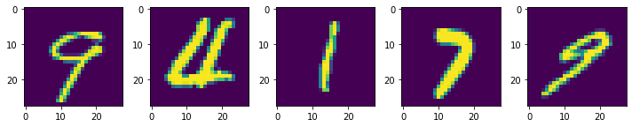

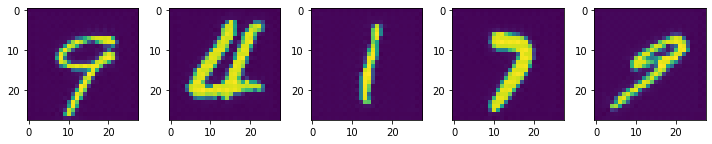

```python
original_test_images = np.squeeze(np.load(os.path.join(os.path.dirname(sys.path[0]), "MNIST_CNN_notebook/Datasets/test_images.npy")))
recreated_test_images = np.squeeze(np.load(os.path.join(os.path.dirname(sys.path[0]), "MNIST_CNN_notebook/Datasets/recreated_test_images.npy")))

# plot some of the original test images
random_indices = random.sample(range(0, len(original_test_images)), 5)
fig1=plt.figure(figsize=(10,5))
for i, index in enumerate(random_indices):
    ax=fig1.add_subplot(1,5,i+1)
    ax.imshow(original_test_images[index])

# plot some recreated images
fig2=plt.figure(figsize=(10,5))
for i, index in enumerate(random_indices):
    ax=fig2.add_subplot(1,5,i+1)
    ax.imshow(recreated_test_images[index])

# show plots (recreated appears under the original)
fig1.tight_layout()
fig2.tight_layout()
plt.show()
```

As you can see, the recreated images are almost identical to the originals, appearing to have slightly less intensity but maintaining the majority of the original information.

To train the next section of the autoencoder, we can reuse the Autoencoder class and the cross_validate_autoencoder() and fit_autoencoder_hyperparameters() methods defined above. We again train an initial version of the most complex architecture (128 filters) to get an idea for how many epochs we will need to train this section of the autoencoder. Below we visualize the training loss and validation loss as a function of epochs trained, using three different learning rates to try and capture the training process under best conditions.

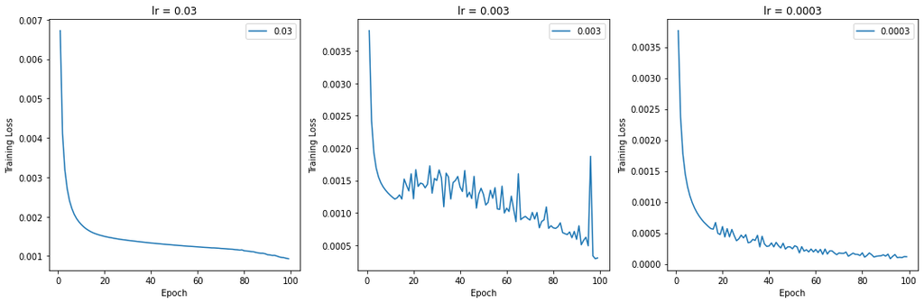

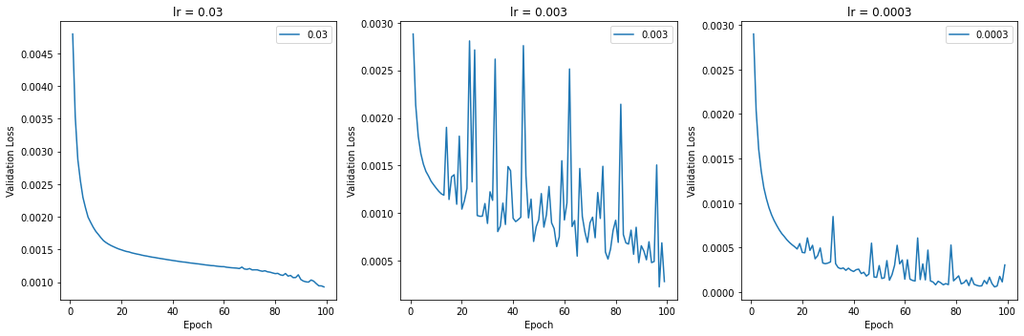

```python
training_losses = pd.read_csv(os.path.join(os.path.dirname(sys.path[0]), "MNIST_CNN_notebook/initial_model_measurements/training_measurements2.csv"), header=0, index_col=0)
validation_losses = pd.read_csv(os.path.join(os.path.dirname(sys.path[0]), "MNIST_CNN_notebook/initial_model_measurements/validation_measurements2.csv"), header=0, index_col=0)

fig1 = plt.figure(figsize=(15,5))
for n, column in enumerate(training_losses.columns):
    ax = fig1.add_subplot(1,3,n+1)
    training_losses.iloc[1:].plot(y=column, use_index=True, ax=ax)
    ax.set_title("lr = " + str(column))
    ax.set_xlabel("Epoch")
    ax.set_ylabel("Training Loss")
fig1.tight_layout()

fig2 = plt.figure(figsize=(15,5))
for n, column in enumerate(validation_losses.columns):
    ax = fig2.add_subplot(1,3,n+1)
    validation_losses.iloc[1:].plot(y=column, use_index=True, ax=ax)
    ax.set_title("lr = " + str(column))
    ax.set_xlabel("Epoch")
    ax.set_ylabel("Validation Loss")
fig2.tight_layout()
plt.show()
```

The measurements above suggest that we should train this section of the autoencoder for at least 50 epochs. We will train for a maximum of 60 with an early stopping tolerance of 5.

Rather than repeat the code here, we reuse the code above and change the names of the csv files used to record evaluation scores. Here are the scores for all number of filters (8, 16, 32, 64, and 128).

```python
from IPython.display import display_html
from itertools import chain,cycle
def display_side_by_side(*args,titles=cycle([''])):
    html_str=''
    for df,title in zip(args, chain(titles,cycle(['</br>'])) ):
        html_str+='<th style="text-align:center"><td style="vertical-align:top">'
        html_str+=f'<h2 style="text-align: center;">{title}</h2>'
        html_str+=df.to_html().replace('table','table style="display:inline"')
        html_str+='</td></th>'
    display_html(html_str,raw=True)

df1 = pd.read_csv(os.path.join(os.path.dirname(sys.path[0]), "MNIST_CNN_notebook/hyperparameter_files/8num_filters2.csv"),
                  header=0, index_col=0).reset_index().drop(columns=["index"]).sort_values("log_likelihood")
df2 = pd.read_csv(os.path.join(os.path.dirname(sys.path[0]), "MNIST_CNN_notebook/hyperparameter_files/16num_filters2.csv"),
                  header=0, index_col=0).reset_index().drop(columns=["index"]).sort_values("log_likelihood")
df3 = pd.read_csv(os.path.join(os.path.dirname(sys.path[0]), "MNIST_CNN_notebook/hyperparameter_files/32num_filters2.csv"),
                  header=0, index_col=0).reset_index().drop(columns=["index"]).sort_values("log_likelihood")
df4 = pd.read_csv(os.path.join(os.path.dirname(sys.path[0]), "MNIST_CNN_notebook/hyperparameter_files/64num_filters2.csv"),
                  header=0, index_col=0).reset_index().drop(columns=["index"]).sort_values("log_likelihood")
df5 = pd.read_csv(os.path.join(os.path.dirname(sys.path[0]), "MNIST_CNN_notebook/hyperparameter_files/128num_filters2.csv"),
                  header=0, index_col=0).reset_index().drop(columns=["index"]).sort_values("log_likelihood")
display_side_by_side(df1,df2,df3,df4,df5, titles=["8 filters","16 filters", "32 filters", "64 filters", "128 filters"])
```

8 filters

|  | lr | weight_decay | dropout | batch_size_exponent | log_likelihood |
| --- | --- | --- | --- | --- | --- |
| 2 | 0.00300 | 0.00010 | 0.000 | 8 | -0.000966 |
| 1 | 0.00300 | 0.00010 | 0.040 | 8 | -0.000717 |
| 3 | 0.00300 | 0.00010 | 0.030 | 8 | -0.000664 |
| 11 | 0.00600 | 0.00020 | 0.005 | 8 | -0.000642 |
| 12 | 0.00150 | 0.00020 | 0.005 | 8 | -0.000540 |
| 0 | 0.00300 | 0.00010 | 0.020 | 8 | -0.000532 |
| 5 | 0.00300 | 0.00010 | 0.015 | 8 | -0.000488 |
| 8 | 0.00300 | 0.00040 | 0.005 | 8 | -0.000484 |
| 4 | 0.00300 | 0.00010 | 0.010 | 8 | -0.000478 |
| 9 | 0.00300 | 0.00030 | 0.005 | 8 | -0.000439 |
| 13 | 0.00450 | 0.00020 | 0.005 | 8 | -0.000432 |
| 6 | 0.00300 | 0.00010 | 0.005 | 8 | -0.000425 |
| 14 | 0.00225 | 0.00020 | 0.005 | 8 | -0.000424 |
| 10 | 0.00300 | 0.00015 | 0.005 | 8 | -0.000412 |
| 7 | 0.00300 | 0.00020 | 0.005 | 8 | -0.000411 |

16 filters

|  | lr | weight_decay | dropout | batch_size_exponent | log_likelihood |
| --- | --- | --- | --- | --- | --- |
| 3 | 0.0090 | 0.000100 | 0.020 | 8 | -0.000195 |
| 14 | 0.0030 | 0.000150 | 0.015 | 8 | -0.000174 |
| 2 | 0.0120 | 0.000100 | 0.020 | 8 | -0.000164 |
| 9 | 0.0030 | 0.000175 | 0.020 | 8 | -0.000163 |
| 6 | 0.0030 | 0.000400 | 0.020 | 8 | -0.000152 |
| 11 | 0.0030 | 0.000150 | 0.040 | 8 | -0.000134 |
| 7 | 0.0030 | 0.000300 | 0.020 | 8 | -0.000134 |
| 13 | 0.0030 | 0.000150 | 0.010 | 8 | -0.000129 |
| 10 | 0.0030 | 0.000125 | 0.020 | 8 | -0.000119 |
| 1 | 0.0060 | 0.000100 | 0.020 | 8 | -0.000113 |
| 5 | 0.0030 | 0.000200 | 0.020 | 8 | -0.000082 |
| 4 | 0.0045 | 0.000100 | 0.020 | 8 | -0.000081 |
| 15 | 0.0030 | 0.000150 | 0.005 | 8 | -0.000080 |
| 0 | 0.0030 | 0.000100 | 0.020 | 8 | -0.000070 |
| 8 | 0.0030 | 0.000150 | 0.020 | 8 | -0.000059 |
| 12 | 0.0030 | 0.000150 | 0.000 | 8 | -0.000047 |

32 filters

|  | lr | weight_decay | dropout | batch_size_exponent | log_likelihood |
| --- | --- | --- | --- | --- | --- |
| 12 | 0.001125 | 0.00030 | 0.01 | 8 | -0.000252 |
| 5 | 0.001575 | 0.00010 | 0.02 | 8 | -0.000252 |
| 2 | 0.000450 | 0.00010 | 0.02 | 8 | -0.000196 |
| 15 | 0.001125 | 0.00000 | 0.01 | 8 | -0.000177 |
| 4 | 0.000675 | 0.00010 | 0.02 | 8 | -0.000169 |
| 7 | 0.001125 | 0.00010 | 0.00 | 8 | -0.000142 |
| 8 | 0.001125 | 0.00010 | 0.03 | 8 | -0.000138 |
| 0 | 0.000900 | 0.00010 | 0.02 | 8 | -0.000135 |
| 1 | 0.001800 | 0.00010 | 0.02 | 8 | -0.000127 |
| 14 | 0.001125 | 0.00020 | 0.01 | 8 | -0.000125 |
| 6 | 0.001125 | 0.00010 | 0.04 | 8 | -0.000123 |
| 11 | 0.001125 | 0.00040 | 0.01 | 8 | -0.000116 |
| 3 | 0.001350 | 0.00010 | 0.02 | 8 | -0.000103 |
| 10 | 0.001125 | 0.00020 | 0.01 | 8 | -0.000088 |
| 13 | 0.001125 | 0.00015 | 0.01 | 8 | -0.000087 |
| 9 | 0.001125 | 0.00010 | 0.01 | 8 | -0.000073 |

64 filters

|  | lr | weight_decay | dropout | batch_size_exponent | log_likelihood |
| --- | --- | --- | --- | --- | --- |
| 13 | 0.00180 | 0.000100 | 0.000 | 8 | -0.000300 |
| 12 | 0.00135 | 0.000050 | 0.000 | 8 | -0.000265 |
| 16 | 0.00180 | 0.000025 | 0.000 | 8 | -0.000206 |
| 1 | 0.00090 | 0.000100 | 0.040 | 8 | -0.000193 |
| 3 | 0.00090 | 0.000100 | 0.010 | 8 | -0.000128 |
| 4 | 0.00090 | 0.000100 | 0.015 | 8 | -0.000121 |
| 14 | 0.00180 | 0.000000 | 0.000 | 8 | -0.000106 |
| 15 | 0.00180 | 0.000075 | 0.000 | 8 | -0.000095 |
| 0 | 0.00090 | 0.000100 | 0.020 | 8 | -0.000092 |
| 5 | 0.00090 | 0.000100 | 0.005 | 8 | -0.000089 |
| 2 | 0.00090 | 0.000100 | 0.000 | 8 | -0.000084 |
| 6 | 0.00090 | 0.000200 | 0.000 | 8 | -0.000083 |
| 7 | 0.00090 | 0.000150 | 0.000 | 8 | -0.000077 |
| 8 | 0.00090 | 0.000050 | 0.000 | 8 | -0.000063 |
| 11 | 0.00270 | 0.000050 | 0.000 | 8 | -0.000049 |
| 10 | 0.00360 | 0.000050 | 0.000 | 8 | -0.000048 |
| 9 | 0.00180 | 0.000050 | 0.000 | 8 | -0.000048 |

128 filters

|  | lr | weight_decay | dropout | batch_size_exponent | log_likelihood |
| --- | --- | --- | --- | --- | --- |
| 10 | 0.0012 | 0.0004 | 0.0200 | 8 | -0.000992 |
| 13 | 0.0012 | 0.0004 | 0.0075 | 8 | -0.000746 |
| 7 | 0.0024 | 0.0004 | 0.0100 | 8 | -0.000619 |
| 5 | 0.0006 | 0.0003 | 0.0100 | 8 | -0.000425 |
| 4 | 0.0006 | 0.0006 | 0.0100 | 8 | -0.000362 |
| 3 | 0.0006 | 0.0008 | 0.0100 | 8 | -0.000361 |
| 0 | 0.0006 | 0.0001 | 0.0100 | 8 | -0.000280 |
| 1 | 0.0006 | 0.0002 | 0.0100 | 8 | -0.000238 |
| 8 | 0.0018 | 0.0004 | 0.0100 | 8 | -0.000214 |
| 2 | 0.0006 | 0.0004 | 0.0100 | 8 | -0.000179 |
| 9 | 0.0009 | 0.0004 | 0.0100 | 8 | -0.000174 |
| 12 | 0.0012 | 0.0004 | 0.0050 | 8 | -0.000170 |
| 14 | 0.0012 | 0.0004 | 0.0025 | 8 | -0.000137 |
| 6 | 0.0012 | 0.0004 | 0.0100 | 8 | -0.000135 |
| 11 | 0.0012 | 0.0004 | 0.0000 | 8 | -0.000049 |

This time around, we can notice some improvement in the score as we increase the number of filters. Although 16 filters was able to reach the same performance as 64 layers, using 64 layers yielded more consistent performances. Using 128 filters does not improve the autoencoder's performance, so we will use 64 filters for the second section. This brings the encoded samples down to 64 x 7 x 7 dimensions. These encoded samples can be subsampled one more time, bringing the filter dimensions down to 4 x 4. After that, it doesn't make sense to downsample anymore since the 5 x 5 downsampling filters will be too large. For the next section of the autoencoder, we will only consider architectures comprised of 64 and 128 filters since the encoded input has 64 channels and it does not make sense to apply a single filter to more than one input channel (which we would have to do in order to reduce the number of channels from 64 to 32, 16, or 8). Let's take the same approach as was taken previously, saving the encoded input produced by the previous section of the autoencoder and using the methods defined above to compare architectures with 64 and 128 filters.

```python
# load encoded training images (each 8 x 14 x 14)
images = t.tensor(np.load(os.path.join(os.path.dirname(sys.path[0]), "MNIST_CNN_notebook/Datasets/encoded_train_images.npy"))

# shuffle dataset
permutation = np.random.permutation(len(images))
images = images[permutation]

# split images into training and validation
cv_size = int(len(images)*0.1) # using ten percent of images for validation
train_images, test_images = images[:-cv_size], images[-cv_size:]

# put input into (0,1) range
normalizing_constant = t.max(train_images).item()
train_images = train_images/normalizing_constant
test_images = test_images/normalizing_constant

# define hyperparameters
num_filters = 64 # best num_filters
dropout = 0.0 # best dropout
lr = 0.0036 #  best lr
weight_decay = 5e-5 # best weight_decay
batch_size_exponent = 8

# define the model
model = AutoEncoder(num_filters, 8, dropout).to(device=device)
optimizer = t.optim.Adam(params=model.parameters(), lr=lr, weight_decay=weight_decay)
criterion = t.nn.MSELoss()
callback_model = None # holds the best validation model during training

# define DataLoaders for training and validating in batches
trainloader = t.utils.data.DataLoader(train_images, batch_size=2**batch_size_exponent, shuffle=True, num_workers=0)
testloader = t.utils.data.DataLoader(test_X, batch_size=2**batch_size_exponent, shuffle=False, num_workers=0)

# train the model
scheduler = t.optim.lr_scheduler.LambdaLR(optimizer, lambda x: 0.95**x)
smallest_validation = np.inf
tolerance_counter = 0
for m in range(60):
    running_loss = 0
    for i, input in enumerate(trainloader):
        optimizer.zero_grad()
        input = input.to(device=device)
        predictions = model(input)
        loss = criterion(predictions, input)
        loss.backward()
        optimizer.step()
        running_loss += loss.item()

    print(f"Epoch {m} loss: {running_loss/math.ceil(len(train_images)/(2**batch_size_exponent))}.")

    running_loss = 0
    with t.no_grad():
        model.eval()
        for i, input in enumerate(testloader):
            input = input.to(device=device)
            validation_predictions = model(input)
            loss = criterion(validation_predictions, input)
            running_loss += loss.item()

    if running_loss >= smallest_validation: tolerance_counter+=1
    else:
        callback_model = deepcopy(model).cpu()
        smallest_validation = running_loss
        tolerance_counter = 0
    if tolerance_counter > 5: break

# save encoded samples
encoded_images = callback_model.encoder(images).detach().numpy()
np.save(os.path.join(os.path.dirname(sys.path[0]), "MNIST_CNN_notebook/Datasets/second_encoded_train_images.npy"), encoded_images)
```

```python
# display comparison of 64 vs 128 filters for the third section of the autoencoder
from IPython.display import display_html
from itertools import chain,cycle
def display_side_by_side(*args,titles=cycle([''])):
    html_str=''
    for df,title in zip(args, chain(titles,cycle(['</br>'])) ):
        html_str+='<th style="text-align:center"><td style="vertical-align:top">'
        html_str+=f'<h2 style="text-align: center;">{title}</h2>'
        html_str+=df.to_html().replace('table','table style="display:inline"')
        html_str+='</td></th>'
    display_html(html_str,raw=True)

df1 = pd.read_csv(os.path.join(os.path.dirname(sys.path[0]), "MNIST_CNN_notebook/hyperparameter_files/64num_filters3.csv"),
                  header=0, index_col=0).reset_index().drop(columns=["index"]).sort_values("log_likelihood")
df2 = pd.read_csv(os.path.join(os.path.dirname(sys.path[0]), "MNIST_CNN_notebook/hyperparameter_files/128num_filters3.csv"),
                  header=0, index_col=0).reset_index().drop(columns=["index"]).sort_values("log_likelihood")

display_side_by_side(df1,df2, titles=["64 filters","128 filters"])
```

64 filters

|  | lr | weight_decay | dropout | batch_size_exponent | log_likelihood |
| --- | --- | --- | --- | --- | --- |
| 9 | 0.000600 | 0.00030 | 0.010 | 8 | -0.000274 |
| 6 | 0.000300 | 0.00030 | 0.040 | 8 | -0.000226 |
| 11 | 0.000450 | 0.00030 | 0.010 | 8 | -0.000203 |
| 7 | 0.000300 | 0.00030 | 0.030 | 8 | -0.000191 |
| 4 | 0.000300 | 0.00015 | 0.010 | 8 | -0.000190 |
| 10 | 0.000150 | 0.00030 | 0.010 | 8 | -0.000180 |
| 2 | 0.000300 | 0.00040 | 0.010 | 8 | -0.000169 |
| 5 | 0.000300 | 0.00030 | 0.020 | 8 | -0.000163 |
| 8 | 0.000300 | 0.00030 | 0.015 | 8 | -0.000162 |
| 0 | 0.000300 | 0.00010 | 0.010 | 8 | -0.000158 |
| 1 | 0.000300 | 0.00020 | 0.010 | 8 | -0.000153 |
| 3 | 0.000300 | 0.00030 | 0.010 | 8 | -0.000146 |
| 12 | 0.000225 | 0.00030 | 0.010 | 8 | -0.000137 |

128 filters

|  | lr | weight_decay | dropout | batch_size_exponent | log_likelihood |
| --- | --- | --- | --- | --- | --- |
| 6 | 0.000300 | 0.00020 | 0.000 | 8 | -0.000210 |
| 12 | 0.000225 | 0.00020 | 0.005 | 8 | -0.000191 |
| 4 | 0.000300 | 0.00015 | 0.010 | 8 | -0.000149 |
| 9 | 0.000600 | 0.00020 | 0.005 | 8 | -0.000145 |
| 3 | 0.000300 | 0.00030 | 0.010 | 8 | -0.000141 |
| 2 | 0.000300 | 0.00040 | 0.010 | 8 | -0.000140 |
| 7 | 0.000300 | 0.00020 | 0.015 | 8 | -0.000128 |
| 0 | 0.000300 | 0.00010 | 0.010 | 8 | -0.000118 |
| 10 | 0.000150 | 0.00020 | 0.005 | 8 | -0.000112 |
| 11 | 0.000450 | 0.00020 | 0.005 | 8 | -0.000099 |
| 5 | 0.000300 | 0.00020 | 0.020 | 8 | -0.000084 |
| 1 | 0.000300 | 0.00020 | 0.010 | 8 | -0.000073 |
| 8 | 0.000300 | 0.00020 | 0.005 | 8 | -0.000068 |

It appears that using 128 filters for the third section of the autoencoder allows it to retain more information than using 64 filters. Now that we have finished tuning each section of the autoencoder, we are ready to combine the encoding sections into the convolutional neural network that we will use to classify the original MNIST images. The final network is defined below. In addition to a convolutional section, it contains a fully-connected (dense) layer at the end which connects the convolutional section to the final output. This dense layer is 2048 wide in order to accomodate the flattened (128 x 4 x 4 = 2048) output of the convolutional section.

```python
class CNN(t.nn.Module):
    def __init__(self, convolution_dropout, dense_dropout):
        super().__init__()

        # entire convolutional network
        self.network = t.nn.Sequential(
            t.nn.Conv2d(1, 8, 3, stride=1, padding=1),
            t.nn.BatchNorm2d(8),
            t.nn.ReLU(inplace=True),
            t.nn.Dropout(convolution_dropout),
            t.nn.Conv2d(8, 8, 3, padding=1),
            t.nn.BatchNorm2d(8),
            t.nn.ReLU(inplace=True),
            t.nn.Dropout(convolution_dropout),
            t.nn.Conv2d(8, 8, kernel_size=5, stride=2, padding=2),
            t.nn.Conv2d(8, 64, 3, stride=1, padding=1),
            t.nn.BatchNorm2d(64),
            t.nn.ReLU(inplace=True),
            t.nn.Dropout(convolution_dropout),
            t.nn.Conv2d(64, 64, 3, padding=1),
            t.nn.BatchNorm2d(64),
            t.nn.ReLU(inplace=True),
            t.nn.Dropout(convolution_dropout),
            t.nn.Conv2d(64, 64, kernel_size=5, stride=2, padding=2),
            t.nn.Conv2d(64, 128, 3, stride=1, padding=1),
            t.nn.BatchNorm2d(128),
            t.nn.ReLU(inplace=True),
            t.nn.Dropout(convolution_dropout),
            t.nn.Conv2d(128, 128, 3, padding=1),
            t.nn.BatchNorm2d(128),
            t.nn.ReLU(inplace=True),
            t.nn.Dropout(convolution_dropout),
            t.nn.Conv2d(128, 128, kernel_size=5, stride=2, padding=2),
            t.nn.BatchNorm2d(128),
            t.nn.ReLU(inplace=True),
            t.nn.Dropout(convolution_dropout),
            t.nn.Flatten(),
            t.nn.Linear(2048, 2048),
            t.nn.BatchNorm1d(2048),
            t.nn.ReLU(inplace=True),
            t.nn.Dropout(dense_dropout),
            t.nn.Linear(2048,10)
        )

    def forward(self, x):
        return self.network(x)
```

The loss function we use to train this network is pytorch's CrossEntropyLoss. This loss function runs the network's output through a softmax function and a negative log likelihood function, which is why we don't define that part of the network. During evaluation, if we wanted to get conditional probability estimates for each class given an input, then we would need to run the output of the network through a softmax activation function.

Before we begin tuning our CNN for good hyperparmeters, let's visualize how the training and validation loss changes as a function of training time. This will give us an idea of how long to train the model for.

```python
images = t.tensor(np.load(os.path.join(os.path.dirname(sys.path[0]), "MNIST_CNN_notebook/Datasets/train_images")).unsqueeze(1)
labels = t.tensor(np.load(os.path.join(os.path.dirname(sys.path[0]), "MNIST_CNN_notebook/Datasets/train_labels")).to(dtype=t.long)

# shuffle dataset
criterion = t.nn.CrossEntropyLoss()
cv_size = int(images.shape[0]*0.1)
train_loss_recordings = pd.DataFrame(columns=["0.03", "0.003", "0.0003"])
validation_loss_recordings = pd.DataFrame(columns=["0.03", "0.003", "0.0003"])

train_images, test_images = images[:-cv_size], images[-cv_size:]
train_labels, test_labels = labels[:-cv_size], labels[-cv_size:]

# put input into (0,1) range
normalizing_constant = t.max(train_images).item()
train_images = train_images/normalizing_constant
test_images = test_images/normalizing_constant

# create pytorch datasets that can be used with Dataloader to get batches
train = t.utils.data.TensorDataset(train_images, train_labels)
test = t.utils.data.TensorDataset(test_images, test_labels)

for lr in [0.03,0.003,0.0003]:
    # define the model
    model = CNN(convolution_dropout=0, dense_dropout=0).to(device=device)
    optimizer = t.optim.Adam(params=model.parameters(), lr=lr)

    # train model
    trainloader = t.utils.data.DataLoader(train, batch_size=2**8, shuffle=True, num_workers=0)
    testloader = t.utils.data.DataLoader(test, batch_size=2**8, shuffle=False, num_workers=0)

    train_losses = []
    validation_losses = []
    for m in range(100): # run for 100 epochs
        running_loss = 0
        model.train()
        correct = 0
        for i, (input, labels) in enumerate(trainloader): # train
            optimizer.zero_grad()
            predictions = model(input.to(device=device))
            loss = criterion(predictions, labels.to(device=device))
            loss.backward()
            optimizer.step()
            running_loss += loss.item()
            predicted = t.max(predictions.data, 1)[1].cpu()
            correct += (predicted == labels).sum()
        print(f"lr {lr}, Epoch {m} training loss: {running_loss/(math.ceil(len(train_images)/(2**8)))}. {correct} out of {len(train_labels)} correct.")
        train_losses.append(running_loss/(math.ceil(len(train_images)/(2**8))))
        running_loss = 0
        model.eval()
        with t.no_grad():
            correct = 0
            for i, (input, labels) in enumerate(testloader): # validate
                validation_predictions = model(input.to(device=device))
                loss = criterion(validation_predictions, labels.to(device=device))
                running_loss += loss.item()
                predicted = t.max(validation_predictions.data, 1)[1].cpu()
                correct += (predicted == labels).sum()
        validation_losses.append(running_loss/(math.ceil(len(test_images)/(2**8))))

        print(f"lr {lr}, Epoch {m} validation loss: {running_loss/(math.ceil(len(test_images)/(2**8)))}. {correct} out of {len(test_labels)} correct.")
    train_loss_recordings[str(lr)] = train_losses
    validation_loss_recordings[str(lr)] = validation_losses
train_loss_recordings.to_csv(os.path.join(os.path.dirname(sys.path[0]), "MNIST_CNN_notebook/initial_model_measurements/cnn_training_measurements.csv")
validation_loss_recordings.to_csv(os.path.join(os.path.dirname(sys.path[0]), "MNIST_CNN_notebook/initial_model_measurements/cnn_validation_measurements.csv"))
```

Let's print the loss measurements:

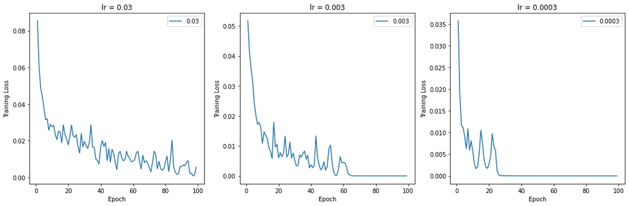

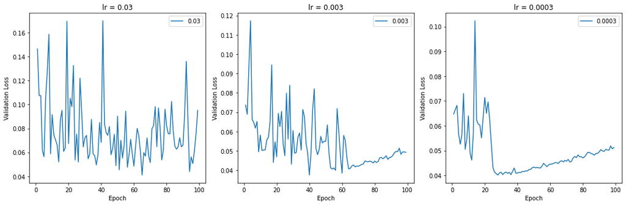

```python
training_losses = pd.read_csv(os.path.join(os.path.dirname(sys.path[0]), "MNIST_CNN_notebook/initial_model_measurements/cnn_training_measurements.csv"), header=0, index_col=0)
validation_losses = pd.read_csv(os.path.join(os.path.dirname(sys.path[0]), "MNIST_CNN_notebook/initial_model_measurements/cnn_validation_measurements.csv"), header=0, index_col=0)

fig1 = plt.figure(figsize=(15,5))
for n, column in enumerate(training_losses.columns):
    ax = fig1.add_subplot(1,3,n+1)
    training_losses.iloc[1:].plot(y=column, use_index=True, ax=ax)
    ax.set_title("lr = " + str(column))
    ax.set_xlabel("Epoch")
    ax.set_ylabel("Training Loss")
fig1.tight_layout()

fig2 = plt.figure(figsize=(15,5))
for n, column in enumerate(validation_losses.columns):
    ax = fig2.add_subplot(1,3,n+1)
    validation_losses.iloc[1:].plot(y=column, use_index=True, ax=ax)
    ax.set_title("lr = " + str(column))
    ax.set_xlabel("Epoch")
    ax.set_ylabel("Validation Loss")
fig2.tight_layout()
plt.show()
```

```python
# a method for cross validation of the CNN model
def cross_validate_CNN(images, labels, num_cvs, optimizer_params, network_params, training_params, print_loss:bool = False): # a method to train and evaluate a model
    # shuffle dataset
    permutation = np.random.permutation(len(images))
    images = images[permutation]
    labels = labels[permutation]

    # perform a cross validation
    criterion = t.nn.CrossEntropyLoss()
    cv_size = int(images.shape[0]/len(images))
    batch_size = 2**training_params["batch_size_exponent"]
    avg_loss = 0
    for n in range(num_cvs):
        # split the dataset into training and cross validation sets:
        if n == num_cvs-1:
            train_images, test_images = images[:-cv_size], images[-cv_size:]
            train_labels, test_labels = labels[:-cv_size], labels[-cv_size:]
        else:
            train_images, test_images = t.cat([images[:cv_size*n], images[cv_size*(n+1):]], dim=0), images[cv_size*n:cv_size*(n+1)]
            train_labels, test_labels = t.cat([labels[:cv_size*n], labels[cv_size*(n+1):]], dim=0), labels[cv_size*n:cv_size*(n+1)]

        # put input into (0,1) range
        normalizing_constant = t.max(train_images).item()
        train_images = train_images/normalizing_constant
        test_images = test_images/normalizing_constant

        train = t.utils.data.TensorDataset(train_images, train_labels)
        test = t.utils.data.TensorDataset(test_images, test_labels)

        # define the model
        model = CNN(**network_params).to(device=device)
        optimizer = t.optim.Adam(params=model.parameters(), **optimizer_params)

        # train model
        smallest_validation = np.inf
        tolerance_counter = 0
        testloader = t.utils.data.DataLoader(test, batch_size=batch_size, shuffle=False, num_workers=0)
        scheduler = t.optim.lr_scheduler.LambdaLR(optimizer, lambda x: 0.95**x)
        for m in range(training_params["max_epochs"]):
            running_loss = 0
            correct = 0
            trainloader = t.utils.data.DataLoader(train, batch_size=batch_size, shuffle=True, num_workers=0)
            model.train()
            for i, (input, labels) in enumerate(trainloader):
                optimizer.zero_grad()
                predictions = model(input.to(device=device))
                loss = criterion(predictions, labels.to(device=device))
                loss.backward()
                optimizer.step()
                running_loss += loss.item()
                predicted = t.max(predictions.data, 1)[1].cpu()
                correct += (predicted == labels).sum()
            scheduler.step()
            if print_loss: print(f"Epoch {m} training loss: {running_loss/(math.ceil(len(train_images)/batch_size))}. {correct} out of {len(train_labels)} correct.")

            running_loss = 0
            correct = 0
            with t.no_grad():
                model.eval()
                for i, (input, labels) in enumerate(testloader):
                    validation_predictions = model(input.to(device=device))
                    loss = criterion(validation_predictions, labels.to(device=device))
                    running_loss += loss.item()
                    predicted = t.max(validation_predictions.data, 1)[1].cpu()
                    correct += (predicted == labels).sum()

            if running_loss >= smallest_validation: tolerance_counter+=1
            else:
                smallest_validation = running_loss
                tolerance_counter = 0
            if print_loss: print(f"Epoch {m} validation loss: {running_loss/(math.ceil(len(test_images)/batch_size))}. {correct} out of {len(test_labels)} correct.")
            if tolerance_counter > training_params["tolerance"]: break
        # using best validation
        avg_loss += smallest_validation/(math.ceil(len(test_images)/batch_size))
    return avg_loss/num_cvs


# a method for tuning hyperparameters of the CNN using the cross validation method defined above
def fit_hyperparameters_CNN(train_images, train_labels, num_cvs, search_distance, csv_file):
    # define cv_function that takes only hyperparameters:
    def cv_function(tracked_hyperparameters:dict):
        # make sure that hyperparameters are valid
        if tracked_hyperparameters["batch_size_exponent"] > 10: return -np.inf
        if tracked_hyperparameters["convolution_dropout"] < 0 or tracked_hyperparameters["convolution_dropout"] > 1: return -np.inf
        if tracked_hyperparameters["dense_dropout"] < 0 or tracked_hyperparameters["dense_dropout"] > 1: return -np.inf
        if tracked_hyperparameters["weight_decay"] < 0: return -np.inf
        if tracked_hyperparameters["lr"] <=0: return -np.inf

        # define network hyperparameters:
        optimizer_params = {}
        optimizer_params["lr"] = tracked_hyperparameters["lr"]
        optimizer_params["weight_decay"] = tracked_hyperparameters["weight_decay"]
        network_params = {}
        network_params["convolution_dropout"] = tracked_hyperparameters["convolution_dropout"]
        network_params["dense_dropout"] = tracked_hyperparameters["dense_dropout"]
        training_params = {}
        training_params["batch_size_exponent"] = tracked_hyperparameters["batch_size_exponent"]
        training_params["max_epochs"] = 45
        training_params["tolerance"] = 5

        # cross validate the model
        return -cross_validate_CNN(train_images, train_labels, num_cvs, optimizer_params, network_params,  training_params, print_loss=False)

    # define hyperparameter information that the search depends on
    tracked_hyperparameter_names = {"lr", "weight_decay", "convolution_dropout", "dense_dropout", "batch_size_exponent"}
    constant_hyperparameters = {}
    integer_hyperparameters = {"batch_size_exponent"}
    list_hyperparameters = {}

    # perform search using cv_function and hyperparameters defined above
    if search_distance is None:
        hyperparameter_search.fit(csv_file, cv_function, tracked_hyperparameter_names, constant_hyperparameters, integer_hyperparameters, list_hyperparameters,
            num_rounds = 1, initial_dirichlet_process_prior=0.5, print_status = True, dtype=np.float64)
    else:
        hyperparameter_search.initial_search(csv_file, cv_function, tracked_hyperparameter_names, constant_hyperparameters, integer_hyperparameters, list_hyperparameters,
            num_rounds = 1, search_distance=search_distance, print_status = True, dtype=np.float64)
```

The following code defines an initial set of hyperparameters, uses them to train the CNN, and records the resulting cross validation evaluation using five folds.

```python
# load data
train_images = t.tensor(np.load(os.path.join(os.path.dirname(sys.path[0]), "MNIST_CNN_notebook/Datasets/train_images.csv"))).unsqueeze(1)
train_labels = t.tensor(np.load(os.path.join(os.path.dirname(sys.path[0]), "MNIST_CNN_notebook/Datasets/train_labels.csv"))).to(dtype=t.long)

# define network hyperparameters:
optimizer_params = {
    "lr": 0.0003,#0.00375,
    "weight_decay": 1e-4 #0.0001125,
}
network_params = {
    "convolution_dropout": 0.01,
    "dense_dropout": 0.1,
}
training_params = {
    "max_epochs":45,
    "batch_size_exponent":8,
    "tolerance":5,
}

# cross validate the model
avg_loss = cross_validate_CNN(train_images, train_labels, 5, optimizer_params, network_params, training_params, print_loss=False)
print(f"Average cross validation loss: {avg_loss}")

# save hyperparameters in csv
csv_folder = os.path.join(os.path.dirname(sys.path[0]), "MNIST_CNN_notebook/hyperparameter_files")
csv_filename = csv_folder + "/" + "CNN.csv"
try:
    hyperparameter_table = pd.read_csv(csv_filename, header=0, index_col=0)
except FileNotFoundError:
    hyperparameter_table = pd.DataFrame(columns=["lr", "weight_decay", "convolution_dropout", "dense_dropout", "batch_size_exponent", "log_likelihood"])
tracked_hyperparameters = {}
tracked_hyperparameters["weight_decay"] = optimizer_params["weight_decay"]
tracked_hyperparameters["convolution_dropout"] = network_params["convolution_dropout"]
tracked_hyperparameters["dense_dropout"] = network_params["dense_dropout"]
tracked_hyperparameters["lr"] = optimizer_params["lr"]
tracked_hyperparameters["batch_size_exponent"] = training_params["batch_size_exponent"]
tracked_hyperparameters["log_likelihood"] = -avg_loss
hyperparameter_table.loc[len(hyperparameter_table.index)] = tracked_hyperparameters
hyperparameter_table.to_csv(csv_filename)
```

This section of code calls the same hyperparameter tuning method that was used to tune the autoencoder sections earlier in the notebook. This time it is used to tune the CNN using the cross validation methods defined above.

```python
# define search space
search_distances = {
    "lr": 1,
    "weight_decay": 1,
    "convolution_dropout": 1,
    "dense_dropout": 1,
    "batch_size_exponent": None
}

# perform search
csv_folder = os.path.join(os.path.dirname(sys.path[0]), "MNIST_CNN_notebook/hyperparameter_files")
csv_file = csv_folder + "/" + "CNN.csv"
train_images = t.tensor(np.load(os.path.join(os.path.dirname(sys.path[0]), "MNIST_CNN_notebook/Datasets/train_images"))).unsqueeze(1)
train_labels = t.tensor(np.load(os.path.join(os.path.dirname(sys.path[0]), "MNIST_CNN_notebook/Datasets/train_labels"))).to(dtype=t.long)
fit_hyperparameters_CNN(train_images, train_labels, 5, search_distances, csv_file)
```

After tuning the hyperparameters of the CNN for a while, we observe the following evaluations.

```python
# load the hyperparameter evaluations
df1 = pd.read_csv(os.path.join(os.path.dirname(sys.path[0]), "MNIST_CNN_notebook/hyperparameter_files/CNN.csv"),
                  header=0, index_col=0).reset_index().drop(columns=["index"]).sort_values("log_likelihood")
df1
```

|  | lr | weight_decay | convolution_dropout | dense_dropout | batch_size_exponent | log_likelihood |
| --- | --- | --- | --- | --- | --- | --- |
| 0 | 0.000300 | 0.000100 | 0.010000 | 0.100000 | 8 | -0.031668 |
| 4 | 0.000300 | 0.000100 | 0.010000 | 0.100000 | 7 | -0.031318 |
| 53 | 0.000244 | 0.000125 | 0.012177 | 0.167735 | 9 | -0.030988 |
| 1 | 0.000300 | 0.000100 | 0.010000 | 0.100000 | 10 | -0.029945 |
| 49 | 0.000245 | 0.000208 | 0.014629 | 0.233721 | 7 | -0.029866 |
| ... | ... | ... | ... | ... | ... | ... |
| 8 | 0.000300 | 0.000100 | 0.010000 | 0.300000 | 6 | -0.023009 |
| 2 | 0.000300 | 0.000100 | 0.010000 | 0.100000 | 6 | -0.022926 |
| 22 | 0.000300 | 0.000150 | 0.000000 | 0.100000 | 6 | -0.022773 |
| 30 | 0.000300 | 0.000150 | 0.020000 | 0.050000 | 6 | -0.022240 |
| 20 | 0.000300 | 0.000150 | 0.010000 | 0.100000 | 6 | -0.021539 |

62 rows × 6 columns

Let's use the best set of hyperparameters observed to train a CNN model on all of the training data and finally make some predictions using the test set that we can submit to Kaggle to measure the effectiveness of our model.

```python
# load original training images
images = t.tensor(np.load(os.path.join(os.path.dirname(sys.path[0]), "MNIST_CNN_notebook/Datasets/train_images.npy"))).unsqueeze(1)
labels = t.tensor(np.load(os.path.join(os.path.dirname(sys.path[0]), "MNIST_CNN_notebook/Datasets/train_labels.npy"))).to(dtype=t.long)

# shuffle dataset
permutation = np.random.permutation(len(images))
images = images[permutation]
labels = labels[permutation]

# split images into training and validation
cv_size = int(len(images)*0.1) # using ten percent of images for validation
train_images, test_images = images[:-cv_size], images[-cv_size:]
train_labels, test_labels = labels[:-cv_size], labels[-cv_size:]

# put input into (0,1) range
normalizing_constant = t.max(train_images).item()
train_images = train_images/normalizing_constant
test_images = test_images/normalizing_constant

train = t.utils.data.TensorDataset(train_images, train_labels)
test = t.utils.data.TensorDataset(test_images, test_labels)

# define hyperparameters
lr = 0.0003 #  best lr
weight_decay = 0.000150 # best weight_decay
convolution_dropout = 0.01 # best dropout
dense_dropout = 0.1
batch_size_exponent = 6
batch_size = 2**batch_size_exponent

# define the model
model = CNN(convolution_dropout, dense_dropout).to(device=device)
optimizer = t.optim.Adam(params=model.parameters(), lr=lr, weight_decay=weight_decay)
criterion = t.nn.CrossEntropyLoss()
callback_model = None # holds the best validation model during training

# define DataLoaders for training and validating in batches
trainloader = t.utils.data.DataLoader(train, batch_size=2**batch_size_exponent, shuffle=True, num_workers=0)
testloader = t.utils.data.DataLoader(test, batch_size=2**batch_size_exponent, shuffle=False, num_workers=0)

# train the model
scheduler = t.optim.lr_scheduler.LambdaLR(optimizer, lambda x: 0.95**x)
smallest_validation = np.inf
tolerance_counter = 0
for m in range(45):
    running_loss = 0
    correct = 0
    model.train()
    for i, (input, labels) in enumerate(trainloader):
        optimizer.zero_grad()
        predictions = model(input.to(device=device))
        loss = criterion(predictions, labels.to(device=device))
        loss.backward()
        optimizer.step()
        running_loss += loss.item()
        predicted = t.max(predictions.data, 1)[1].cpu()
        correct += (predicted == labels).sum()
    scheduler.step()
    print(f"Epoch {m} training loss: {running_loss/(math.ceil(len(train_images)/batch_size))}. {correct} out of {len(train_labels)} correct.")

    running_loss = 0
    correct = 0
    with t.no_grad():
        model.eval()
        for i, (input, labels) in enumerate(testloader):
            validation_predictions = model(input.to(device=device))
            loss = criterion(validation_predictions, labels.to(device=device))
            running_loss += loss.item()
            predicted = t.max(validation_predictions.data, 1)[1].cpu()
            correct += (predicted == labels).sum()

    if running_loss >= smallest_validation: tolerance_counter+=1
    else:
        smallest_validation = running_loss
        tolerance_counter = 0
        callback_model = deepcopy(model)
    print(f"Epoch {m} validation loss: {running_loss/(math.ceil(len(test_images)/batch_size))}. {correct} out of {len(test_labels)} correct.")
    if tolerance_counter > 5: break

# load test images
test_images = t.tensor(np.load(os.path.join(os.path.dirname(sys.path[0]), "MNIST_CNN_notebook/Datasets/test_images.npy"))).unsqueeze(1) / normalizing_constant
loader = t.utils.data.DataLoader(test_images, batch_size=2048, shuffle=False, num_workers=0)

# make predictions
predictions = []
callback_model.eval()
for input in loader:
    predictions.append(t.max(callback_model(input.to(device=device)).data,1)[1].cpu())
predictions = t.concat(predictions,dim=0)


# format and save predictions for submission
results = pd.Series(predictions, name="Label")
submission = pd.concat([pd.Series(range(1,28001),name = "ImageId"), results],axis = 1)
submission.to_csv(os.path.join(os.path.dirname(sys.path[0]), "MNIST_CNN_notebook/submissions/single_cnn.csv"),index=False)
```

```
Epoch 0 training loss: 0.12607420845526113. 36284 out of 37800 correct.
Epoch 0 validation loss: 0.060317652839743954. 4122 out of 4200 correct.
Epoch 1 training loss: 0.04730127945458816. 37230 out of 37800 correct.
Epoch 1 validation loss: 0.06369927712137613. 4117 out of 4200 correct.
Epoch 2 training loss: 0.03285923567862532. 37377 out of 37800 correct.
Epoch 2 validation loss: 0.04767799166394539. 4136 out of 4200 correct.
Epoch 3 training loss: 0.025561293710989155. 37489 out of 37800 correct.
Epoch 3 validation loss: 0.04866629694835424. 4137 out of 4200 correct.
Epoch 4 training loss: 0.02133389645198584. 37532 out of 37800 correct.
Epoch 4 validation loss: 0.049517487347739836. 4137 out of 4200 correct.
Epoch 5 training loss: 0.017961265714665758. 37593 out of 37800 correct.
Epoch 5 validation loss: 0.03618922557330789. 4155 out of 4200 correct.
Epoch 6 training loss: 0.01805514966280715. 37583 out of 37800 correct.
Epoch 6 validation loss: 0.042222578975435514. 4148 out of 4200 correct.
Epoch 7 training loss: 0.014468349068138596. 37638 out of 37800 correct.
Epoch 7 validation loss: 0.043137601476205004. 4147 out of 4200 correct.
Epoch 8 training loss: 0.012064763476998055. 37672 out of 37800 correct.
Epoch 8 validation loss: 0.04714450703503451. 4145 out of 4200 correct.
Epoch 9 training loss: 0.009635922388445866. 37693 out of 37800 correct.
Epoch 9 validation loss: 0.04599280101617544. 4153 out of 4200 correct.
Epoch 10 training loss: 0.009497288284175627. 37704 out of 37800 correct.
Epoch 10 validation loss: 0.034780173791329035. 4154 out of 4200 correct.
Epoch 11 training loss: 0.009978550428945363. 37695 out of 37800 correct.
Epoch 11 validation loss: 0.04659200080619264. 4148 out of 4200 correct.
Epoch 12 training loss: 0.007630543014443954. 37723 out of 37800 correct.
Epoch 12 validation loss: 0.0454272670319893. 4156 out of 4200 correct.
Epoch 13 training loss: 0.00696546459785137. 37724 out of 37800 correct.
Epoch 13 validation loss: 0.03476224902260583. 4161 out of 4200 correct.
Epoch 14 training loss: 0.003955069287624344. 37768 out of 37800 correct.
Epoch 14 validation loss: 0.0342691060425502. 4163 out of 4200 correct.
Epoch 15 training loss: 0.005424248166360645. 37751 out of 37800 correct.
Epoch 15 validation loss: 0.04432827845360435. 4147 out of 4200 correct.
Epoch 16 training loss: 0.005107758631913012. 37757 out of 37800 correct.
Epoch 16 validation loss: 0.035959208091354056. 4162 out of 4200 correct.
Epoch 17 training loss: 0.00391719776474892. 37767 out of 37800 correct.
Epoch 17 validation loss: 0.03660796305815562. 4153 out of 4200 correct.
Epoch 18 training loss: 0.004598714636111641. 37765 out of 37800 correct.
Epoch 18 validation loss: 0.031155995907311357. 4167 out of 4200 correct.
Epoch 19 training loss: 0.004905062323869892. 37761 out of 37800 correct.
Epoch 19 validation loss: 0.03147141597119943. 4166 out of 4200 correct.
Epoch 20 training loss: 0.0017558185996729234. 37791 out of 37800 correct.
Epoch 20 validation loss: 0.04031478353709011. 4157 out of 4200 correct.
Epoch 21 training loss: 0.003400159322485515. 37767 out of 37800 correct.
Epoch 21 validation loss: 0.049509108188706734. 4152 out of 4200 correct.
Epoch 22 training loss: 0.004393750310512244. 37754 out of 37800 correct.
Epoch 22 validation loss: 0.03661039243668325. 4158 out of 4200 correct.
Epoch 23 training loss: 0.00275899993334822. 37776 out of 37800 correct.
Epoch 23 validation loss: 0.036365594978137364. 4158 out of 4200 correct.
Epoch 24 training loss: 0.001824678496201365. 37787 out of 37800 correct.
Epoch 24 validation loss: 0.032236823934715976. 4169 out of 4200 correct.
```

This submission achieved 99.2% accuracy on the hidden dataset. Let's try using an ensemble of these networks to reduce the variability of our predictions. We will train 15 networks and use bagging to make predictions.

```python
# load original training images
images = t.tensor(np.load(os.path.join(os.path.dirname(sys.path[0]), "MNIST_CNN_notebook/Datasets/train_images.npy"))).unsqueeze(1)
image_labels = t.tensor(np.load(os.path.join(os.path.dirname(sys.path[0]), "MNIST_CNN_notebook/Datasets/train_labels.npy"))).to(dtype=t.long)

# define a file to hold the ensemble of networks
ensemble_filename = os.path.join(os.path.dirname(sys.path[0]), "MNIST_CNN_notebook/models/cnn_ensemble")
ensemble = []

# train 15 cnn models
for n in range(15):

    # shuffle dataset
    permutation = np.random.permutation(len(images))
    images = images[permutation]
    image_labels = image_labels[permutation]


    # split images into training and validation
    cv_size = int(len(images)*0.1) # using ten percent of images for validation
    train_images, test_images = images[:-cv_size], images[-cv_size:]
    train_labels, test_labels = image_labels[:-cv_size], image_labels[-cv_size:]

    # put input into (0,1) range
    normalizing_constant = t.max(train_images).item()
    train_images = train_images/normalizing_constant
    test_images = test_images/normalizing_constant

    train = t.utils.data.TensorDataset(train_images, train_labels)
    test = t.utils.data.TensorDataset(test_images, test_labels)

    # define hyperparameters
    lr = 0.0003 #  best lr
    weight_decay = 0.000150 # best weight_decay
    convolution_dropout = 0.01 # best dropout
    dense_dropout = 0.1
    batch_size_exponent = 6
    batch_size = 2**batch_size_exponent

    # define the model
    model = CNN(convolution_dropout, dense_dropout).to(device=device)
    model.normalizing_constant = normalizing_constant # save the normalizing constant for making predictions
    optimizer = t.optim.Adam(params=model.parameters(), lr=lr, weight_decay=weight_decay)
    criterion = t.nn.CrossEntropyLoss()
    callback_model = None # holds the best validation model during training

    # define DataLoaders for training and validating in batches
    trainloader = t.utils.data.DataLoader(train, batch_size=2**batch_size_exponent, shuffle=True, num_workers=0)
    testloader = t.utils.data.DataLoader(test, batch_size=2**batch_size_exponent, shuffle=False, num_workers=0)

    # train the model
    scheduler = t.optim.lr_scheduler.LambdaLR(optimizer, lambda x: 0.95**x)
    smallest_validation = np.inf
    largest_accuracy = 0
    tolerance_counter = 0
    for m in range(45):
        running_loss = 0
        correct = 0
        model.train()
        for i, (input, labels) in enumerate(trainloader):
            optimizer.zero_grad()
            predictions = model(input.to(device=device))
            loss = criterion(predictions, labels.to(device=device))
            loss.backward()
            optimizer.step()
            running_loss += loss.item()
            predicted = t.max(predictions.data, 1)[1].cpu()
            correct += (predicted == labels).sum()
        scheduler.step()

        running_loss = 0
        correct = 0
        with t.no_grad():
            model.eval()
            for i, (input, labels) in enumerate(testloader):
                validation_predictions = model(input.to(device=device))
                loss = criterion(validation_predictions, labels.to(device=device))
                running_loss += loss.item()
                predicted = t.max(validation_predictions.data, 1)[1].cpu()
                correct += (predicted == labels).sum()

        if running_loss >= smallest_validation: tolerance_counter+=1
        else:
            smallest_validation = running_loss
            largest_accuracy = correct/len(test_labels)
            tolerance_counter = 0
            callback_model = deepcopy(model)
        if tolerance_counter > 5: break

    # save model once it has been trained in case an error arises
    ensemble.append(callback_model)
    with open(ensemble_filename, "wb") as file:
        pickle.dump(ensemble, file)
    print(f"Network {n} finished training with {largest_accuracy*100:.4g}% accuracy.")
```

```
Network 0 finished training with 99.55% accuracy.
Network 1 finished training with 99.38% accuracy.
Network 2 finished training with 99.4% accuracy.
Network 3 finished training with 99.07% accuracy.
Network 4 finished training with 99.21% accuracy.
Network 5 finished training with 99.55% accuracy.
Network 6 finished training with 99.5% accuracy.
Network 7 finished training with 99.14% accuracy.
Network 8 finished training with 99.48% accuracy.
Network 9 finished training with 99.43% accuracy.
Network 10 finished training with 99.6% accuracy.
Network 11 finished training with 99.12% accuracy.
Network 12 finished training with 99.29% accuracy.
Network 13 finished training with 99.05% accuracy.
Network 14 finished training with 99.29% accuracy.
```

```python
# Now that all 15 networks have been trained, we can use them to make bagged predictions

# load test images
test_images = t.tensor(np.load(os.path.join(os.path.dirname(sys.path[0]), "MNIST_CNN_notebook/Datasets/test_images.npy"))).unsqueeze(1)
loader = t.utils.data.DataLoader(test_images, batch_size=2048, shuffle=False, num_workers=0)

# load model
with open(ensemble_filename, "rb") as file:
    ensemble = pickle.load(file)

# make predictions
ensemble_predictions = []
for network in ensemble:
    single_network_predictions = []
    callback_model.eval()
    for input in loader:
        input = input / network.normalizing_constant
        single_network_predictions.append(t.max(callback_model(input.to(device=device)).data,1)[1].cpu())
    ensemble_predictions.append(t.concat(single_network_predictions,dim=0)[:,None])
ensemble_predictions = t.concat(ensemble_predictions, dim=1)
ensemble_predictions = t.mode(ensemble_predictions, dim=1)[0]

# format and save predictions for submission
ensemble_predictions = pd.Series(ensemble_predictions, name="Label")
submission = pd.concat([pd.Series(range(1,28001),name = "ImageId"), ensemble_predictions],axis = 1)
submission.to_csv(os.path.join(os.path.dirname(sys.path[0]), "MNIST_CNN_notebook/submissions/ensemble_cnn.csv"),index=False)
```

This ensemble of networks acheived 99.4% accuracy, a slight improvement over a single network. The highest accuracy ever acheived by convolutional neural networks on this hidden MNIST handwritten digits is 99.8%. The difference between our network and more accurate ones is that higher performing networks were trained using data augmentation, in which the images in the training dataset are altered slightly to produce additional samples, increasing the total pool of samples upon which the network can be trained. We could implement data augmentation here and likely increase the accuracy of our model by a couple of decimal percentage points, but training it would require more computational power and time than I have at my disposal. If you would like to see an implementation of data augmentation on this dataset, check out this great (and high scoring) Kaggle notebook: https://www.kaggle.com/code/cdeotte/25-million-images-0-99757-mnist/notebook#Accuracy=99.75%-using-25-Million-Training-Images.

Thanks for following along with this notebook. This was my first time implementing autoencoders and I think that the approach this notebook takes towards developing a convolutional neural network architecture is really effective. Whether it is the most efficient approach depends on the problem. For many problems, transfer learning, in which an a network architecture is derived from another network that was effective on a similar problem, is a quicker route to a high-performing model. As uncertainty about the effectiveness of using transfer learning increases, the approach outlined here becomes a more viable alternative.

If you have any questions or comments about this notebook, I do enjoy discussing math and machine learning. You can find my contact information on the homepage of my website: https://tobibutler.github.io/TobiButler-github.io/.